# HR Employee Attrition

## Objective

We have to investigate that,how the company objective factors influence in attrition of employees,and what kind of working enviroment most will cause employees attrition and to create a model that can predict if a certain employee will leave the company or not.The goal is to create or improve different retention strategies on targeted employees.Overall,the implementation of this model will allow management to create better decision-making actions

### Loading the data

```r
setwd("E:/intershala/1452762979_586__HR_Employee_Attrition_Data.csv.zip_attachment_658891")
HR_emp_att<-read.csv("HR_Employee_Attrition_Data.csv",header = T,sep = ",",na.strings = c("",NA))
```

### Required library

```r
library(ggplot2)
library(data.table)
library(highcharter)
library(caret)
library(VIM)
library(dplyr)
library(plyr)
library(caTools)
library(gridExtra)
library(randomForest)
library(Metrics)
library(pROC)
library(e1071)
library(dtree)
library(corrplot)
library(DMwR)
library(xgboost)
```

### View the data

```r
dim(HR_emp_att)
```

```
[1] 2940   35
```

```r
str(HR_emp_att)
```

```
'data.frame':   2940 obs. of  35 variables:
 $ Age                     : int  41 49 37 33 27 32 59 30 38 36 ...
 $ Attrition               : Factor w/ 2 levels "No","Yes": 2 1 2 1 1 1 1 1 1 1 ...
 $ BusinessTravel          : Factor w/ 3 levels "Non-Travel","Travel_Frequently",..: 3 2 3 2 3 2 3 3 2 3 ...
 $ DailyRate               : int  1102 279 1373 1392 591 1005 1324 1358 216 1299 ...
 $ Department              : Factor w/ 3 levels "Human Resources",..: 3 2 2 2 2 2 2 2 2 2 ...
 $ DistanceFromHome        : int  1 8 2 3 2 2 3 24 23 27 ...
 $ Education               : int  2 1 2 4 1 2 3 1 3 3 ...
 $ EducationField          : Factor w/ 6 levels "Human Resources",..: 2 2 5 2 4 2 4 2 2 4 ...
 $ EmployeeCount           : int  1 1 1 1 1 1 1 1 1 1 ...
 $ EmployeeNumber          : int  1 2 3 4 5 6 7 8 9 10 ...
 $ EnvironmentSatisfaction : int  2 3 4 4 1 4 3 4 4 3 ...
 $ Gender                  : Factor w/ 2 levels "Female","Male": 1 2 2 1 2 2 1 2 2 2 ...
 $ HourlyRate              : int  94 61 92 56 40 79 81 67 44 94 ...
 $ JobInvolvement          : int  3 2 2 3 3 3 4 3 2 3 ...
```

[output cut: 21 more lines]

```r
#To know number of unique values in each variable
sapply(HR_emp_att, function(x) length(unique(x)))
```

```
                     Age                Attrition
                      43                        2
          BusinessTravel                DailyRate
                       3                      886
              Department         DistanceFromHome
                       3                       29
               Education           EducationField
                       5                        6
           EmployeeCount           EmployeeNumber
                       1                     2940
 EnvironmentSatisfaction                   Gender
                       4                        2
              HourlyRate           JobInvolvement
                      71                        4
                JobLevel                  JobRole
                       5                        9
         JobSatisfaction            MaritalStatus
                       4                        3
           MonthlyIncome              MonthlyRate
                    1349                     1427
      NumCompaniesWorked                   Over18
                      10                        1
                OverTime        PercentSalaryHike
                       2                       15
       PerformanceRating RelationshipSatisfaction
                       2                        4
           StandardHours         StockOptionLevel
                       1                        4
       TotalWorkingYears    TrainingTimesLastYear
                      40                        7
         WorkLifeBalance           YearsAtCompany
                       4                       37
      YearsInCurrentRole  YearsSinceLastPromotion
                      19                       16
    YearsWithCurrManager
                      18
```

### checking overall summary of the Data

```r
summary(HR_emp_att)
```

```
      Age        Attrition            BusinessTravel
 Min.   :18.00   No :2466   Non-Travel       : 300
 1st Qu.:30.00   Yes: 474   Travel_Frequently: 554
 Median :36.00              Travel_Rarely    :2086
 Mean   :36.92
 3rd Qu.:43.00
 Max.   :60.00

   DailyRate                       Department   DistanceFromHome
 Min.   : 102.0   Human Resources       : 126   Min.   : 1.000
 1st Qu.: 465.0   Research & Development:1922   1st Qu.: 2.000
 Median : 802.0   Sales                 : 892   Median : 7.000
 Mean   : 802.5                                 Mean   : 9.193
 3rd Qu.:1157.0                                 3rd Qu.:14.000
 Max.   :1499.0                                 Max.   :29.000

   Education              EducationField EmployeeCount
 Min.   :1.000   Human Resources :  54   Min.   :1
 1st Qu.:2.000   Life Sciences   :1212   1st Qu.:1
 Median :3.000   Marketing       : 318   Median :1
 Mean   :2.913   Medical         : 928   Mean   :1
 3rd Qu.:4.000   Other           : 164   3rd Qu.:1
 Max.   :5.000   Technical Degree: 264   Max.   :1

 EmployeeNumber   EnvironmentSatisfaction    Gender
 Min.   :   1.0   Min.   :1.000           Female:1176
 1st Qu.: 735.8   1st Qu.:2.000           Male  :1764
 Median :1470.5   Median :3.000
 Mean   :1470.5   Mean   :2.722
 3rd Qu.:2205.2   3rd Qu.:4.000
 Max.   :2940.0   Max.   :4.000

   HourlyRate     JobInvolvement    JobLevel
 Min.   : 30.00   Min.   :1.00   Min.   :1.000
 1st Qu.: 48.00   1st Qu.:2.00   1st Qu.:1.000
 Median : 66.00   Median :3.00   Median :2.000
 Mean   : 65.89   Mean   :2.73   Mean   :2.064
 3rd Qu.: 84.00   3rd Qu.:3.00   3rd Qu.:3.000
 Max.   :100.00   Max.   :4.00   Max.   :5.000

```

[output cut: 40 more lines]

```
 YearsAtCompany   YearsInCurrentRole YearsSinceLastPromotion
 Min.   : 0.000   Min.   : 0.000     Min.   : 0.000
 1st Qu.: 3.000   1st Qu.: 2.000     1st Qu.: 0.000
 Median : 5.000   Median : 3.000     Median : 1.000
 Mean   : 7.008   Mean   : 4.229     Mean   : 2.188
 3rd Qu.: 9.000   3rd Qu.: 7.000     3rd Qu.: 3.000
 Max.   :40.000   Max.   :18.000     Max.   :15.000

 YearsWithCurrManager
 Min.   : 0.000
 1st Qu.: 2.000
 Median : 3.000
 Mean   : 4.123
 3rd Qu.: 7.000
 Max.   :17.000
```

As we saw in the Data Observations 2,940 and Variables 35

response variable is Attrition with 2466 ‘NO’ and 474 ‘Yes’ that shows the unbalance class label. we have to pay attention to the unbalance class algorithm problems!

Employee Count is equal 1 for all observation which can not generate useful value for this sample data. Maybe for the other sample of data will be with different values that should be considered for builiding the model in the future for other sets of data. In this analysis, we will remove it.

Over 18 is equal to ‘Y’, which means employee is not less than 18 years old. this attribute should be considered for the future, maybe by changing the ruls of emploement, young people under 18 can also working in companies. Here, according to the data set, we will remove it.

Moreover, Standard Hours is equal 80 for all observation. the decision for this attribute is same like Over18 and Employee Count.

BusinessTravel, Department, EducationField, Gender, jobRole, MaritalStatus and OverTime are categorical data and other variabels are continues.

Some of variables are related to the years of working wich can be a good candidate for feature generation.

Some of variable are related to personal issues like WorkLifeBalance, RelationshipSatisfaction, JobSatisfaction,EnvironmentSatisfaction etc.

There are some variables that are related to the income like MonthlyIncome, PercentSalaryHike etc.

EmployeeNumber is a variable for identifying the specific employee.If we have more information about employee and the structure of the employee number, then we can extract some new features. But now it is not possible and we have to remove it from our data set.

```r
# Checking for missing values.
sapply(HR_emp_att, function(x) sum(is.na(x)))
```

```
                     Age                Attrition
                       0                        0
          BusinessTravel                DailyRate
                       0                        0
              Department         DistanceFromHome
                       0                        0
               Education           EducationField
                       0                        0
           EmployeeCount           EmployeeNumber
                       0                        0
 EnvironmentSatisfaction                   Gender
                       0                        0
              HourlyRate           JobInvolvement
                       0                        0
                JobLevel                  JobRole
                       0                        0
         JobSatisfaction            MaritalStatus
                       0                        0
           MonthlyIncome              MonthlyRate
                       0                        0
      NumCompaniesWorked                   Over18
                       0                        0
                OverTime        PercentSalaryHike
                       0                        0
       PerformanceRating RelationshipSatisfaction
                       0                        0
           StandardHours         StockOptionLevel
                       0                        0
       TotalWorkingYears    TrainingTimesLastYear
                       0                        0
         WorkLifeBalance           YearsAtCompany
                       0                        0
      YearsInCurrentRole  YearsSinceLastPromotion
                       0                        0
    YearsWithCurrManager
                       0
```

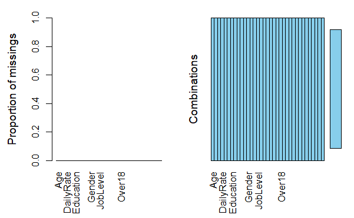

```r
# checking the variable importance
VIM::aggr(HR_emp_att)
```

No Missing Value,we shall Remove non value attributes because These variables can not play significant role because they are same for all records.EmployeeNumber can be accepted as an indicator for the time of join to the company which can be used for new feature generation,But we do not have any meta data about it, then, we will remove it.

```r
# Removing non value attributes
HR_emp_att$EmployeeNumber<- NULL
HR_emp_att$StandardHours <- NULL
HR_emp_att$Over18 <- NULL
HR_emp_att$EmployeeCount <- NULL
cat("Data Set has ",dim(HR_emp_att)[1], " Rows and ", dim(HR_emp_att)[2], " Columns" )
```

```
Data Set has  2940  Rows and  31  Columns
```

##### There are some attributes that are categorical, but in the data set are integer. We have to change them to categorical.

```r
# changing the class of variables
HR_emp_att$Education <- factor(HR_emp_att$Education)
HR_emp_att$EnvironmentSatisfaction <- factor(HR_emp_att$EnvironmentSatisfaction)
HR_emp_att$JobInvolvement <- factor(HR_emp_att$JobInvolvement)
HR_emp_att$JobLevel <- factor(HR_emp_att$JobLevel)
HR_emp_att$JobSatisfaction <- factor(HR_emp_att$JobSatisfaction)
HR_emp_att$PerformanceRating <- factor(HR_emp_att$PerformanceRating)
HR_emp_att$RelationshipSatisfaction <- factor(HR_emp_att$RelationshipSatisfaction)
HR_emp_att$StockOptionLevel <- factor(HR_emp_att$StockOptionLevel)
HR_emp_att$WorkLifeBalance <- factor(HR_emp_att$WorkLifeBalance)
```

## Exploratory Data Analysis

```r
g1 <- ggplot(HR_emp_att, aes(x = MonthlyIncome, fill = Attrition)) + geom_density(alpha = 0.7) + scale_fill_manual(values = c("#386cb0","#fdb462"))
### Attrition - log(Monthly Income)
g2<-ggplot(HR_emp_att, aes(x =  log(MonthlyIncome), fill = Attrition,colour = Attrition, alpha = .3)) + geom_density() + ggtitle("")
g3 <- ggplot(HR_emp_att, aes(x = HourlyRate, fill = Attrition)) + geom_density(alpha = 0.7) + scale_fill_manual(values = c("#386cb0","#fdb462"))
g4 <- ggplot(HR_emp_att, aes(x = DailyRate, fill = Attrition)) + geom_density(alpha = 0.7) + scale_fill_manual(values = c("#386cb0","#fdb462"))
g5 <- ggplot(HR_emp_att, aes(x = MonthlyRate, fill = Attrition)) + geom_density(alpha = 0.7) + scale_fill_manual(values = c("#386cb0","#fdb462"))
grid.arrange(g1, g2, g3, g4,g5, ncol = 2, nrow = 3)
```

[output not shown]

We can only make few observations from the plot.It seems fair to say that a large majority of those who left had a relatively lower monthly income and daily rate while the never made it in majority into the higher hourly rate group. On the other hand, the differences become elusive when comparing the monthly rate.

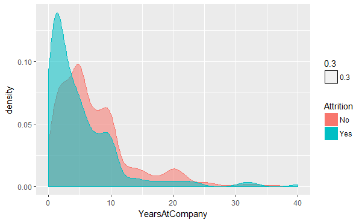

```r
### YearsAtCompany - Attrition
ggplot(HR_emp_att, aes(x = YearsAtCompany, fill = Attrition, colour = Attrition, alpha = .3)) + geom_density()
```

large majority of employee those who left were between 0 to 12 year at company

```r
### Count - EducationField
attrition_edufield <- HR_emp_att %>%select(Attrition, EducationField) %>%group_by(Attrition, EducationField)
attrition_edufield<-count(attrition_edufield)
# creating datatable
library(DT)
datatable(attrition_edufield)
```

|  | Attrition | EducationField | freq |
| --- | --- | --- | --- |
| 1 | No | Human Resources | 40 |
| 2 | No | Life Sciences | 1034 |
| 3 | No | Marketing | 248 |
| 4 | No | Medical | 802 |
| 5 | No | Other | 142 |
| 6 | No | Technical Degree | 200 |
| 7 | Yes | Human Resources | 14 |
| 8 | Yes | Life Sciences | 178 |
| 9 | Yes | Marketing | 70 |
| 10 | Yes | Medical | 126 |

[output cut: 2 more lines]

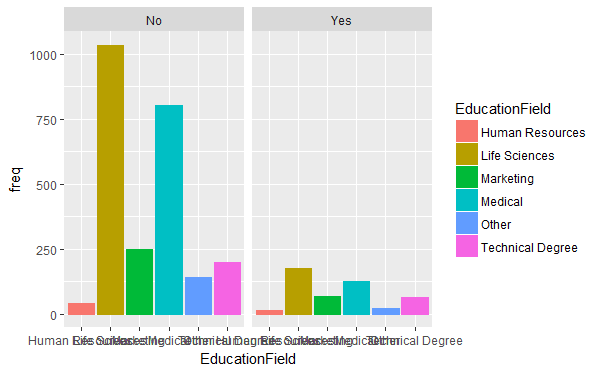

```r
ggplot(attrition_edufield, aes(x = EducationField,y = freq,fill = EducationField, colour = EducationField))+ geom_bar(stat = "identity") + facet_wrap(~Attrition)
```

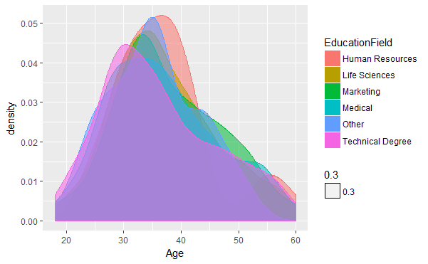

```r
ggplot(HR_emp_att, aes(x = Age, fill = EducationField,colour = EducationField, alpha = .3)) + geom_density()
```

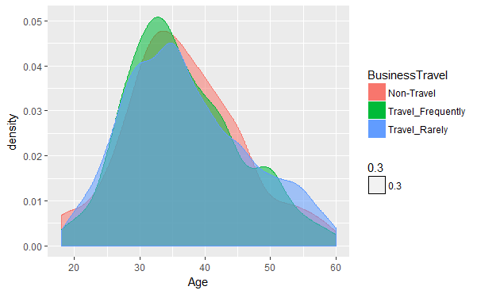

```r
ggplot(HR_emp_att, aes(x =  Age, fill = BusinessTravel,colour = BusinessTravel, alpha = .3)) + geom_density()
```

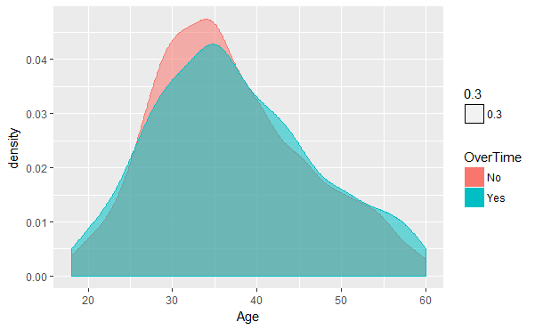

```r
### Distribution of Age/Overtime
ggplot(HR_emp_att, aes(x =  Age, fill = OverTime, colour = OverTime, alpha = .3)) +geom_density()
```

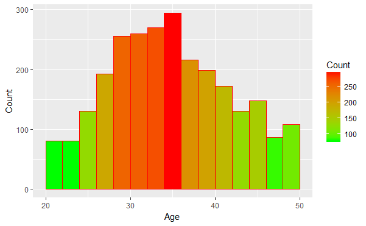

```r
### Distribution of Age
ggplot(data=HR_emp_att, aes(HR_emp_att$Age)) + geom_histogram(breaks=seq(20, 50, by=2),
col="red",aes(fill=..count..))+ labs(x="Age", y="Count")+ scale_fill_gradient("Count", low="green", high="red")
```

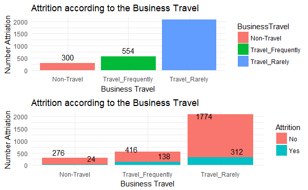

```r
# Exploring BusinessTravel variable
a1 <- HR_emp_att %>%group_by(BusinessTravel) %>% tally() %>%ggplot(aes(x = BusinessTravel, y = n,fill=BusinessTravel)) +
  geom_bar(stat = "identity") +theme_minimal()+ labs(x="Business Travel", y="Number Attriation")+
  ggtitle("Attrition according to the Business Travel")+geom_text(aes(label = n), vjust = -0.5, position = position_dodge(0.9))

a2<- HR_emp_att %>% group_by(BusinessTravel, Attrition) %>%tally() %>%ggplot(aes(x = BusinessTravel, y = n,fill=Attrition)) +
  geom_bar(stat = "identity") + theme_minimal()+ labs(x="Business Travel", y="Number Attriation")+
  ggtitle("Attrition according to the Business Travel")+geom_text(aes(label = n), vjust = -0.5, position = position_dodge(0.9))

grid.arrange(a1,a2)
```

above is the distribution of the data according to the Business Travel situation.more than 70% of employees travel rarely and 10 % of them has no travel and 20% of them are travel frequently

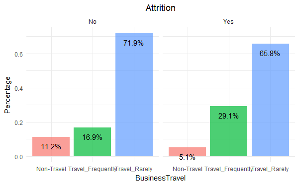

```r
HR_emp_att %>%ggplot(aes(x = BusinessTravel, group = Attrition)) +geom_bar(aes(y = ..prop.., fill = factor(..x..)),
stat="count",alpha = 0.7) +geom_text(aes(label = scales::percent(..prop..), y = ..prop.. ),
stat= "count",vjust = 2) +labs(y = "Percentage", fill= "business Travel") + facet_grid(~Attrition) +
theme_minimal()+theme(legend.position = "none", plot.title = element_text(hjust = 0.5)) + ggtitle("Attrition")
```

As it is obvious from the above plot that majority of employee those who Travel_Rarely had left Furthermore, there seems to be a clear indication that those who left travelled more frequently compared to others. This might have also been an important reason behind their resignation. Here I presume that travelling means staying somewhere else overnight, or for a longer period of time, which is why we may connect this to work-life balance issues

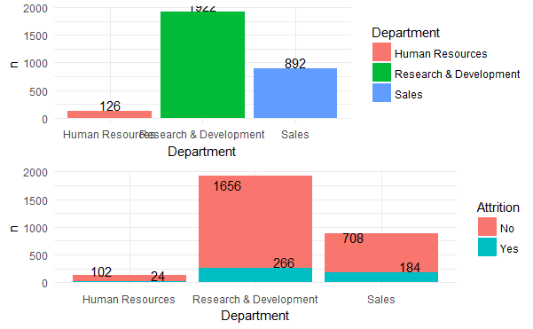

```r
# Exploring variable Department
g1 <- HR_emp_att %>%group_by(Department) %>%tally() %>%ggplot(aes(x = Department, y = n,fill=Department)) +
  geom_bar(stat = "identity") + theme_minimal()+geom_text(aes(label = n), vjust = -0.1, position = position_dodge(0.9))

g2 <- HR_emp_att %>%group_by(Department, Attrition) %>%tally() %>%ggplot(aes(x = Department, y = n,fill=Attrition)) +
  geom_bar(stat = "identity") +theme_minimal()+geom_text(aes(label = n), vjust = -0.1, position = position_dodge(0.9))

grid.arrange(g1,g2)
```

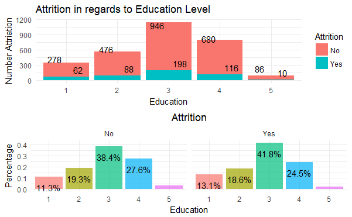

```r
# Exploring the Variable Education
g1<- HR_emp_att %>%group_by(Education, Attrition) %>%tally() %>%ggplot(aes(x = Education, y = n,fill=Attrition)) +
  geom_bar(stat = "identity") + theme_minimal()+geom_text(aes(label = n), vjust = -0.5, position = position_dodge(0.9))+
  labs(x="Education", y="Number Attriation")+ggtitle("Attrition in regards to Education Level")
g2<- HR_emp_att %>%ggplot(aes(x = Education, group = Attrition)) +geom_bar(aes(y = ..prop.., fill = factor(..x..)),
stat="count",alpha = 0.7) + geom_text(aes(label = scales::percent(..prop..), y = ..prop.. ),
stat= "count",vjust = 2) +labs(y = "Percentage", fill= "Education") + facet_grid(~Attrition) +
theme_minimal()+ theme(legend.position = "none", plot.title = element_text(hjust = 0.5)) + ggtitle("Attrition")
grid.arrange(g1,g2)
```

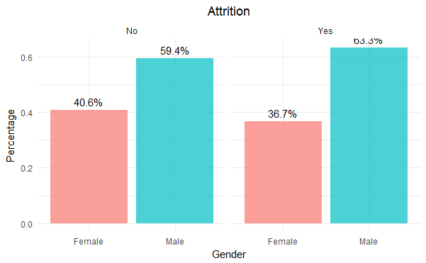

```r
# Exploring the Variable Gender
HR_emp_att %>%ggplot(aes(x = Gender, group = Attrition)) +geom_bar(aes(y = ..prop.., fill = factor(..x..)),
stat="count",alpha = 0.7) + geom_text(aes(label = scales::percent(..prop..), y = ..prop.. ),
stat= "count",vjust = -.5) +labs(y = "Percentage", fill= "Gender") + facet_grid(~Attrition) +
theme_minimal()+theme(legend.position = "none", plot.title = element_text(hjust = 0.5)) + ggtitle("Attrition")
```

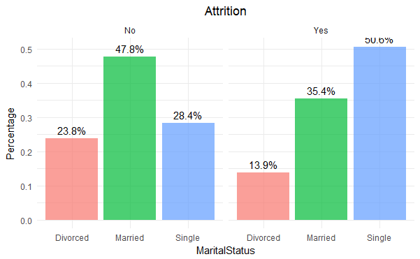

```r
# Exploring the variable MaritalStatus
HR_emp_att %>%ggplot(aes(x = MaritalStatus, group = Attrition)) +geom_bar(aes(y = ..prop.., fill = factor(..x..)),
stat="count",alpha = 0.7) +geom_text(aes(label = scales::percent(..prop..), y = ..prop.. ),
stat= "count",vjust = -.5) +labs(y = "Percentage", fill= "MaritalStatus") + facet_grid(~Attrition) +
theme_minimal()+ theme(legend.position = "none", plot.title = element_text(hjust = 0.5)) +ggtitle("Attrition")
```

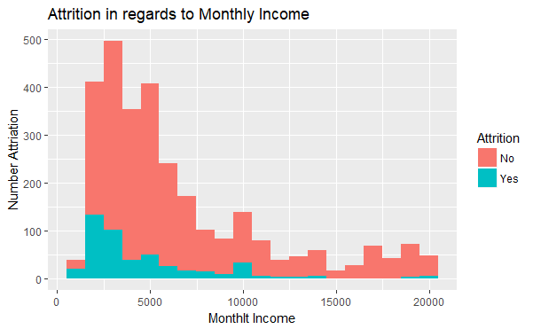

```r
# exploring the Variable MonthlyIncome
HR_emp_att %>%ggplot(mapping = aes(x = MonthlyIncome)) + geom_histogram(aes(fill = Attrition), bins=20)+
  labs(x="Monthlt Income", y="Number Attriation")+ ggtitle("Attrition in regards to Monthly Income")
```

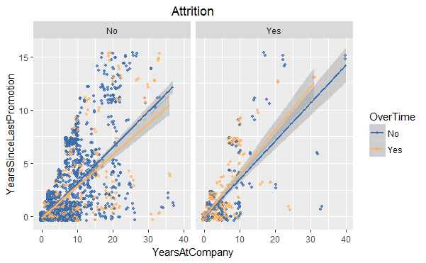

```r
# Exploring the Variable OverTime
ggplot(HR_emp_att, aes(y = YearsSinceLastPromotion, x = YearsAtCompany, colour = OverTime)) + geom_jitter(size = 1, alpha = 0.7) +
geom_smooth(method = "gam") + facet_wrap(~ Attrition) + ggtitle("Attrition") + scale_colour_manual(values = c("#386cb0","#fdb462")) +
theme(plot.title = element_text(hjust = 0.5))
```

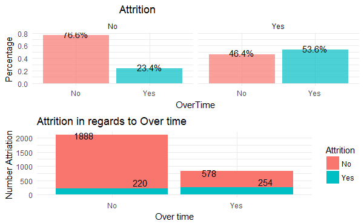

```r
g1 <-HR_emp_att %>%ggplot(aes(x = OverTime, group = Attrition)) + geom_bar(aes(y = ..prop.., fill = factor(..x..)),
stat="count",alpha = 0.7) + geom_text(aes(label = scales::percent(..prop..), y = ..prop.. ),
stat= "count",vjust = 0.3) +labs(y = "Percentage", fill= "OverTime") +facet_grid(~Attrition) +
theme_minimal()+ theme(legend.position = "none", plot.title = element_text(hjust = 0.3)) +
ggtitle("Attrition")

g2 <-HR_emp_att %>% group_by(OverTime, Attrition) %>% tally() %>% ggplot(aes(x = OverTime, y = n,fill=Attrition)) +
  geom_bar(stat = "identity") + theme_minimal()+ geom_text(aes(label = n), vjust = -0.3, position = position_dodge(0.9))+
  labs(x="Over time", y="Number Attriation")+ggtitle("Attrition in regards to Over time")

grid.arrange(g1,g2)
```

First graph shows Years at company in relation to Years since last promotion, grouped by both attrition and overtime. This is an interesting issue, since a high correlation between these two variables (longer you are in the company, less chance you have to be promoted, so to speak) may mean that people are not really growing within the company. However, since this is a simulated dataset we cannot compare it with some norms outside it, so we can compare certain groups within our set, e.g. those who are working overtime and those who are not.

Here we can note two things. Firstly, there is a relatively higher percentage of people working overtime in the group of those who left, an observation confirmed by our barchart. Secondly, while things seem to be going in the right direction for the group of people who still work for the IBM (higher correlation between years since last promotion and years at company for those who don’t work overtime), the opposite is happening in the other group. It seems that there may be a pattern of people leaving because they are not promoted although they work hard. This is only an assumption at this point, since the confidence intervals (gray area around the lines) are getting wider, meaning there is not that much certainty about this, especially at higher values of X and Y (due to the lack of data).

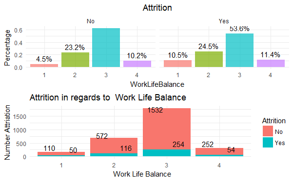

```r
# Exploring the Variable WorklifeBalance
g1<-HR_emp_att%>%ggplot(aes(x = WorkLifeBalance, group = Attrition)) + geom_bar(aes(y = ..prop.., fill = factor(..x..)),
stat="count", alpha = 0.7) +geom_text(aes(label = scales::percent(..prop..), y = ..prop.. ),
stat= "count", vjust = -.5) +labs(y = "Percentage", fill= "WorkLifeBalance") +
facet_grid(~Attrition) + theme_minimal()+ theme(legend.position = "none", plot.title = element_text(hjust = 0.5)) +
ggtitle("Attrition")
g2<- HR_emp_att %>% group_by(WorkLifeBalance, Attrition) %>% tally() %>% ggplot(aes(x = WorkLifeBalance, y = n,fill=Attrition)) +
geom_bar(stat = "identity") + theme_minimal()+geom_text(aes(label = n), vjust = -0.5, position = position_dodge(0.9))+
labs(x="  Work Life Balance", y="Number Attriation") + ggtitle("Attrition in regards to  Work Life Balance")
grid.arrange(g1,g2)
```

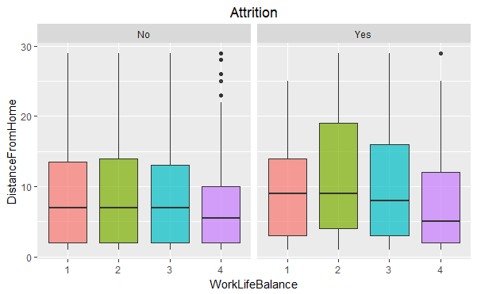

```r
# Exploring the Variables WorkLifeBalance and DistanceFromHome
ggplot(HR_emp_att,aes(x= WorkLifeBalance, y=DistanceFromHome, group = WorkLifeBalance, fill = WorkLifeBalance)) +
geom_boxplot(alpha=0.7) + theme(legend.position="none") + facet_wrap(~ Attrition) + ggtitle("Attrition") +
theme(plot.title = element_text(hjust = 0.5))
```

We can see that there are some patterns in the work-life balance if we compare the two groups within the Attrition variable.

Those who rated their work-life balance relatively low were commuting from a bit farther away in comparison with those who rated their work-life balance as very good. This difference is more pronounced in the group of those who are not in the company anymore, suggesting a possibly influential attrition factor. If the distance is measured in kilometers or miles, this of course doesn’t represent a long distance, but since we’re dealing with a simulated dataset, it might play a role in predicting our attrition class.

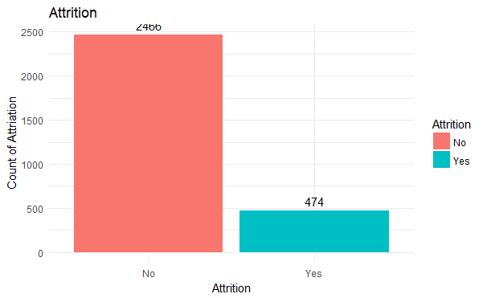

```r
# visualization of Attrition
HR_emp_att %>% group_by(Attrition) %>% tally() %>%ggplot(aes(x = Attrition, y = n,fill=Attrition)) +
  geom_bar(stat = "identity") + theme_minimal()+ labs(x="Attrition", y="Count of Attriation")+
  ggtitle("Attrition")+ geom_text(aes(label = n), vjust = -0.5, position = position_dodge(0.9))
```

As it is obvious from the above graph, there is a great imbalance between the two classes and we are encountered an unbalanced classification problem. In order to handle this issue we utilize the SMOTE method which can generate a new smoothed data set that addresses the class unbalance problem.we will balance the data later now we will build model on row data.

```r
# data preparation
rfData <- HR_emp_att
set.seed(123)
indexes = sample(1:nrow(rfData), size=0.8*nrow(rfData))
RFRaw.train.Data <- rfData[indexes,]
RFRaw.test.Data <- rfData[-indexes,]
```

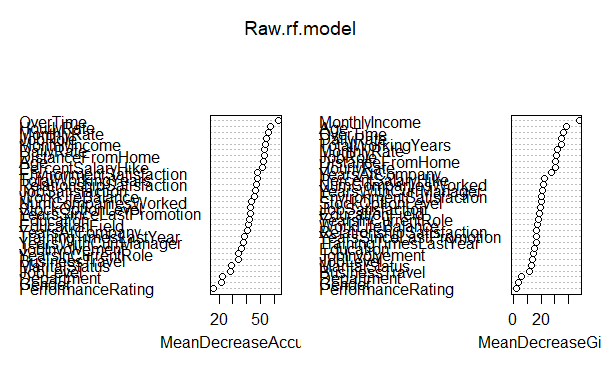

```r
# Building the model
Raw.rf.model <- randomForest(Attrition~.,RFRaw.train.Data, importance=TRUE,ntree=1000)
# plotting variable importance
varImpPlot(Raw.rf.model)
```

As we see here, Over time, Age, MonthlyIncome, Jobrole and TotalWorkingYears are top five variables.

```r
Raw.rf.prd <- predict(Raw.rf.model, newdata = RFRaw.test.Data)
confusionMatrix(RFRaw.test.Data$Attrition, Raw.rf.prd)
```

```
Confusion Matrix and Statistics

          Reference
Prediction  No Yes
       No  507   0
       Yes  10  71

               Accuracy : 0.983
                 95% CI : (0.9689, 0.9918)
    No Information Rate : 0.8793
    P-Value [Acc > NIR] : < 2.2e-16

                  Kappa : 0.9245
 Mcnemar's Test P-Value : 0.004427

            Sensitivity : 0.9807
            Specificity : 1.0000
         Pos Pred Value : 1.0000
         Neg Pred Value : 0.8765
             Prevalence : 0.8793
         Detection Rate : 0.8622
   Detection Prevalence : 0.8622
      Balanced Accuracy : 0.9903

       'Positive' Class : No
```

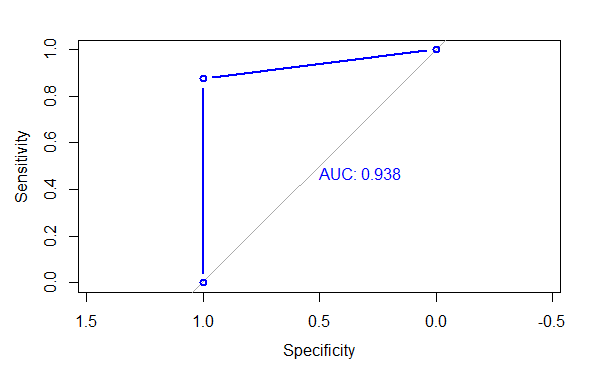

```r
Raw.rf.plot<- plot.roc(as.numeric(RFRaw.test.Data$Attrition), as.numeric(Raw.rf.prd),lwd=2, type="b",print.auc=TRUE,col ="blue")
```

Acc = 0.983 which is very good result, We see that the AUC is 0.938

### Feature Engineering

1- Now we want to use some data wrapping to make the results better: Making Age Group 18-24 = Young , 25-54=Middle-Age , 54-120= Adult

```r
HR_emp_att$AgeGroup <- as.factor(ifelse(HR_emp_att$Age<=24,"Young", ifelse(HR_emp_att$Age<=54,"Middle-Age","Adult")))
table(HR_emp_att$AgeGroup)
```

```
     Adult Middle-Age      Young
       138       2608        194
```

2- Creating a new variable Tot.Satisfaction i.e. the total of the satisfaction from JobEnvironment,JobInvolvement,JobSatisfaction,RelationshipSatisfaction,TotlaSatisfaction etc.

```r
HR_emp_att$Tot.Satisfaction <-
  as.numeric(HR_emp_att$EnvironmentSatisfaction)+
  as.numeric(HR_emp_att$JobInvolvement)+
  as.numeric(HR_emp_att$JobSatisfaction)+
  as.numeric(HR_emp_att$RelationshipSatisfaction)+
  as.numeric(HR_emp_att$WorkLifeBalance)
```

```r
summary(HR_emp_att$Tot.Satisfaction)
```

```
   Min. 1st Qu.  Median    Mean 3rd Qu.    Max.
   6.00   12.00   14.00   13.65   15.00   20.00
```

3- Study Years for getting Education Level certificate  
table(HR_emp_att$Education) As we see here, there are five Education level From high School to PhD (HighSchool=10 years, College=2 years, Bachelor=4 years,Master=2 years,PhD= four years)

```r
HR_emp_att$YearsEducation <-  ifelse(HR_emp_att$Education==1,10,ifelse(HR_emp_att$Education==2,12,
                                  ifelse(HR_emp_att$Education==3,16,ifelse(HR_emp_att$Education==4,18,22))))
table(HR_emp_att$YearsEducation)
```

```
  10   12   16   18   22
 340  564 1144  796   96
```

> we used culumative years for any level

```r
# Creating a new feature IncomeLevel
HR_emp_att$IncomeLevel<-as.factor(ifelse(HR_emp_att$MonthlyIncome<ave(HR_emp_att$MonthlyIncome),"Low","High"))
table(HR_emp_att$IncomeLevel)
```

```
High  Low
 986 1954
```

[figure not shown]

```r
# Let see the Correlation Matrix of Data
corrplot(cor(sapply(HR_emp_att,as.integer)),method = "pie")
```

We can see some of variables are high correlated As an Example : JobLevel and MonthlyIncome Education and YearsEducation

They cause multicollinearity problem in our data set,so we have to deciede to remove one of them for any group Now we try again our data set with new attributes using Random Forest

### New Random Forest

data preparation

```r
rfData <- HR_emp_att
set.seed(123)
indexes = sample(1:nrow(rfData), size=0.8*nrow(rfData))
RFtrain.Data <- rfData[indexes,]
RFtest.Data <- rfData[-indexes,]
```

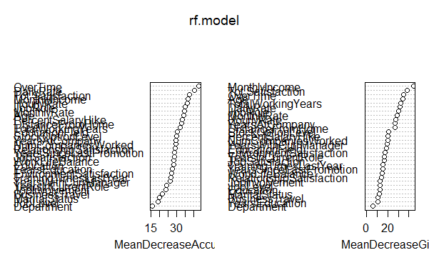

```r
rf.model <- randomForest(Attrition~.,RFtrain.Data, importance=TRUE,ntree=500)
varImpPlot(rf.model)
```

Here we see: OverTime, TotalSatisfaction (New Feature),MonthlyIncome, Age and TotalWorkingYears are top five variables.

```r
rf.prd <- predict(rf.model, newdata = RFtest.Data)
confusionMatrix(RFtest.Data$Attrition, rf.prd)
```

```
Confusion Matrix and Statistics

          Reference
Prediction  No Yes
       No  507   0
       Yes  10  71

               Accuracy : 0.983
                 95% CI : (0.9689, 0.9918)
    No Information Rate : 0.8793
    P-Value [Acc > NIR] : < 2.2e-16

                  Kappa : 0.9245
 Mcnemar's Test P-Value : 0.004427

            Sensitivity : 0.9807
            Specificity : 1.0000
         Pos Pred Value : 1.0000
         Neg Pred Value : 0.8765
             Prevalence : 0.8793
         Detection Rate : 0.8622
   Detection Prevalence : 0.8622
      Balanced Accuracy : 0.9903

       'Positive' Class : No
```

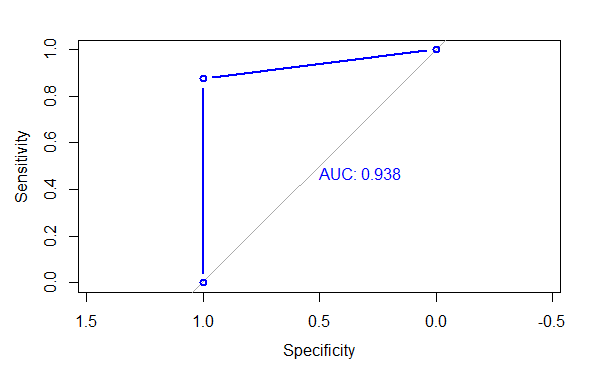

```r
rf.Plot<- plot.roc (as.numeric(RFtest.Data$Attrition), as.numeric(rf.prd),lwd=2, type="b", print.auc=TRUE,col ="blue")
```

### Using other algorithms

#### Using Support Vector Machine

```r
# Data Preparation
svmData <- HR_emp_att
set.seed(123)
indexes = sample(1:nrow(svmData), size=0.8*nrow(svmData))
SVMtrain.Data <- svmData[indexes,]
SVMtest.Data <- svmData[-indexes,]
```

```r
# Building SVM Model
tuned <- tune(svm,factor(Attrition)~.,data = SVMtrain.Data)
svm.model <- svm(SVMtrain.Data$Attrition~., data=SVMtrain.Data
                 ,type="C-classification", gamma=tuned$best.model$gamma
                 ,cost=tuned$best.model$cost
                 ,kernel="radial")
svm.prd <- predict(svm.model,newdata=SVMtest.Data)
confusionMatrix(svm.prd,SVMtest.Data$Attrition)
```

```
Confusion Matrix and Statistics

          Reference
Prediction  No Yes
       No  507  49
       Yes   0  32

               Accuracy : 0.9167
                 95% CI : (0.8913, 0.9377)
    No Information Rate : 0.8622
    P-Value [Acc > NIR] : 3.112e-05

                  Kappa : 0.5297
 Mcnemar's Test P-Value : 7.025e-12

            Sensitivity : 1.0000
            Specificity : 0.3951
         Pos Pred Value : 0.9119
         Neg Pred Value : 1.0000
             Prevalence : 0.8622
         Detection Rate : 0.8622
   Detection Prevalence : 0.9456
      Balanced Accuracy : 0.6975

       'Positive' Class : No
```

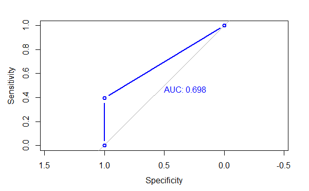

```r
# ploting ROC curve
svm.plot <-plot.roc (as.numeric(SVMtest.Data$Attrition), as.numeric(svm.prd),lwd=2, type="b", print.auc=TRUE,col ="blue")
```

As we see, in compare to RF, Accuracy is lower to 0.9167 and AUC to 0.698 which is not better than RF.

### Decision Tree

Here Dtree will be investigated and compared to other approaches. DTree selected because it is a very good algorithm for interpretion for non-technical.

```r
# Data preparation
DtData <- HR_emp_att
set.seed(123)
indexes = sample(1:nrow(DtData), size=0.8*nrow(DtData))
DTtrain.Data <- DtData[indexes,]
DTtest.Data <- DtData[-indexes,]
```

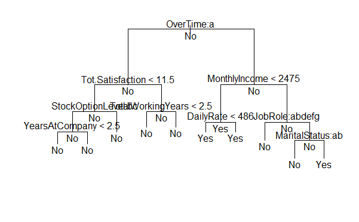

```r
# Building Decision Tree
dtree.model <- tree::tree (Attrition ~., data = DTtrain.Data)
plot(dtree.model)
text(dtree.model, all = T)
```

```r
dtree.prd <- predict(dtree.model, DTtest.Data, type = "class")
confusionMatrix(dtree.prd,DTtest.Data$Attrition)
```

```
Confusion Matrix and Statistics

          Reference
Prediction  No Yes
       No  489  57
       Yes  18  24

               Accuracy : 0.8724
                 95% CI : (0.8428, 0.8983)
    No Information Rate : 0.8622
    P-Value [Acc > NIR] : 0.2579

                  Kappa : 0.3269
 Mcnemar's Test P-Value : 1.145e-05

            Sensitivity : 0.9645
            Specificity : 0.2963
         Pos Pred Value : 0.8956
         Neg Pred Value : 0.5714
             Prevalence : 0.8622
         Detection Rate : 0.8316
   Detection Prevalence : 0.9286
      Balanced Accuracy : 0.6304

       'Positive' Class : No
```

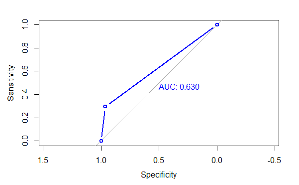

```r
dtree.plot <- plot.roc (as.numeric(DTtest.Data$Attrition), as.numeric(dtree.prd),lwd=2, type="b", print.auc=TRUE, col ="blue")
```

Not very nice result! Accuracy is 0.8724 where AUC is 0.630 which is not better than SVM

### Exterme Gradient Boost

```r
# Exterme Gradient Boost
set.seed(123)
xgbData <- HR_emp_att
indexes <- sample(1:nrow(xgbData), size=0.8*nrow(xgbData))
XGBtrain.Data <- xgbData[indexes,]
XGBtest.Data <- xgbData[-indexes,]
```

```r
formula = Attrition~.
fitControl <- trainControl(method="cv", number = 3,classProbs = TRUE)
xgbGrid <- expand.grid(nrounds = 50,max_depth = 12,eta = .03,gamma = 0.01,colsample_bytree = .7,min_child_weight = 1,subsample = 0.9)
XGB.model <- train(formula, data = XGBtrain.Data,method = "xgbTree"
,trControl = fitControl,verbose=0,maximize=FALSE,tuneGrid = xgbGrid)
importance <- varImp(XGB.model)
varImportance <- data.frame(Variables = row.names(importance[[1]]),
Importance = round(importance[[1]]$Overall,2))
```

```r
# Create a rank variable based on importance of variables
rankImportance <- varImportance %>% mutate(Rank = paste0('#',dense_rank(desc(Importance))))
```

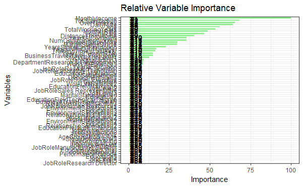

```r
ggplot(rankImportance, aes(x = reorder(Variables, Importance),
y = Importance)) +geom_bar(stat='identity',colour="white", fill = "lightgreen") +geom_text(aes(x = Variables, y = 1, label = Rank),
hjust=0, vjust=.5, size = 4, colour = 'black',fontface = 'bold') +
labs(x = 'Variables', title = 'Relative Variable Importance') +
coord_flip() + theme_bw()
```

As we see above: MonthlyIncome, DailyRate, OvertimeYes, TotalSatisfaction and Age are top five attributes.

```r
XGB.prd <- predict(XGB.model,XGBtest.Data)
confusionMatrix(XGB.prd, XGBtest.Data$Attrition)
```

```
Confusion Matrix and Statistics

          Reference
Prediction  No Yes
       No  505  25
       Yes   2  56

               Accuracy : 0.9541
                 95% CI : (0.9339, 0.9695)
    No Information Rate : 0.8622
    P-Value [Acc > NIR] : 1.862e-13

                  Kappa : 0.7805
 Mcnemar's Test P-Value : 2.297e-05

            Sensitivity : 0.9961
            Specificity : 0.6914
         Pos Pred Value : 0.9528
         Neg Pred Value : 0.9655
             Prevalence : 0.8622
         Detection Rate : 0.8588
   Detection Prevalence : 0.9014
      Balanced Accuracy : 0.8437

       'Positive' Class : No
```

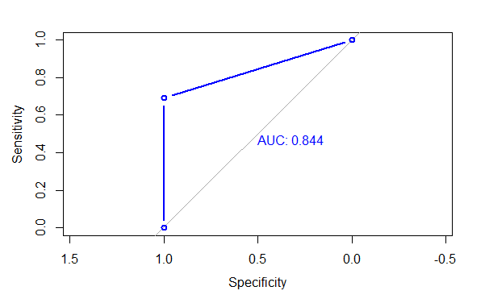

```r
XGB.plot <- plot.roc (as.numeric(XGBtest.Data$Attrition), as.numeric(XGB.prd),lwd=2, type="b", print.auc=TRUE,col ="blue")
```

### Solving Unbalanced Problem

As we mentioned before there is unbalanced problem in class label. There are some approaches to solve the problem. here we use SMOT method.

```r
Classcount = table(HR_emp_att$Attrition)
Classcount
```

```
  No  Yes
2466  474
```

```r
# Over Sampling
over = ( (0.6 * max(Classcount)) - min(Classcount) ) / min(Classcount)
# Under Sampling
under = (0.4 * max(Classcount)) / (min(Classcount) * over)
over = round(over, 1) * 100
under = round(under, 1) * 100
#Generate the balanced data set
BalancedData = SMOTE(Attrition~., HR_emp_att, perc.over = over, k = 5, perc.under = under)
```

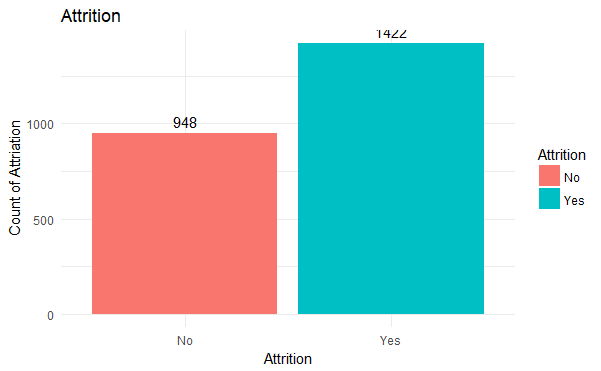

```r
# let check the output of the Balancing
BalancedData %>%group_by(Attrition) %>%tally() %>%ggplot(aes(x = Attrition, y = n,fill=Attrition)) +geom_bar(stat = "identity") +
theme_minimal()+labs(x="Attrition", y="Count of Attriation")+
ggtitle("Attrition")+geom_text(aes(label = n), vjust = -0.5, position = position_dodge(0.9))
```

#### Now we try to run again Random Forest with the Balanced Data

```r
# Balanced Data
set.seed(123)
RF_Bal_Data <- BalancedData
indexes = sample(1:nrow(RF_Bal_Data), size=0.8*nrow(RF_Bal_Data))
RF_BLtrain.Data <- RF_Bal_Data[indexes,]
RF_BLtest.Data <- RF_Bal_Data[-indexes,]
```

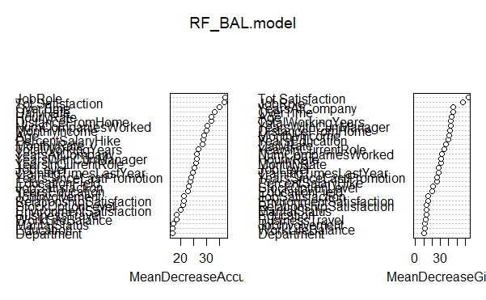

```r
# Random Forest Model
RF_BAL.model <- randomForest(Attrition~.,RF_BLtrain.Data, importance=TRUE,ntree=500)
varImpPlot(RF_BAL.model)
```

```r
RF_BAL.prd <- predict(RF_BAL.model, newdata = RF_BLtest.Data)
confusionMatrix(RF_BLtest.Data$Attrition, RF_BAL.prd)
```

```
Confusion Matrix and Statistics

          Reference
Prediction  No Yes
       No  167  25
       Yes  10 272

               Accuracy : 0.9262
                 95% CI : (0.8988, 0.948)
    No Information Rate : 0.6266
    P-Value [Acc > NIR] : < 2e-16

                  Kappa : 0.8449
 Mcnemar's Test P-Value : 0.01796

            Sensitivity : 0.9435
            Specificity : 0.9158
         Pos Pred Value : 0.8698
         Neg Pred Value : 0.9645
             Prevalence : 0.3734
         Detection Rate : 0.3523
   Detection Prevalence : 0.4051
      Balanced Accuracy : 0.9297

       'Positive' Class : No
```

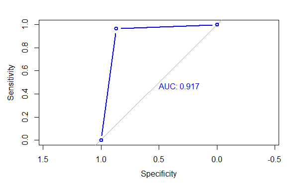

```r
# roc
RF_BAL.Plot<- plot.roc (as.numeric(RF_BLtest.Data$Attrition), as.numeric(RF_BAL.prd),lwd=2, type="b", print.auc=TRUE,col ="blue")
```